# Datenanalyse Bachelor

Dragan Jovanovic

24 8 2022

```r
library(mosaic)
library(rlang)
library(readr)
DatensatzAktuell1 <- read_delim("Datensatzaktuell1.csv", #ROhdatensatz einlesen
    delim = ";", escape_double = FALSE, trim_ws = TRUE)
summary(DatensatzAktuell1)
```

```
##       CASE        SERIAL          REF            QUESTNNR
##  Min.   :102.0   Mode:logical   Mode:logical   Length:233
##  1st Qu.:403.0   NA's:233       NA's:233       Class :character
##  Median :487.0                                 Mode  :character
##  Mean   :478.1
##  3rd Qu.:594.0
##  Max.   :694.0
##      MODE             STARTED               SD01          SD02_01
##  Length:233         Length:233         Min.   :1.000   Min.   :20.00
##  Class :character   Class :character   1st Qu.:1.000   1st Qu.:24.00
##  Mode  :character   Mode  :character   Median :2.000   Median :26.00
##                                        Mean   :1.695   Mean   :27.93
##                                        3rd Qu.:2.000   3rd Qu.:29.00
##                                        Max.   :3.000   Max.   :80.00
##     SD03_01            D01             D02             D03
##  Min.   : 1.000   Min.   :1.000   Min.   :1.000   Min.   :1.000
##  1st Qu.: 2.000   1st Qu.:4.000   1st Qu.:2.000   1st Qu.:3.000
##  Median : 4.000   Median :5.000   Median :3.000   Median :3.000
##  Mean   : 5.245   Mean   :4.858   Mean   :3.335   Mean   :3.549
##  3rd Qu.: 6.000   3rd Qu.:6.000   3rd Qu.:4.000   3rd Qu.:5.000
##  Max.   :60.000   Max.   :7.000   Max.   :7.000   Max.   :7.000
##       D04             D05             D06             D07
##  Min.   :1.000   Min.   :1.000   Min.   :1.000   Min.   :2.000
##  1st Qu.:2.000   1st Qu.:2.000   1st Qu.:2.000   1st Qu.:4.000
##  Median :3.000   Median :3.000   Median :3.000   Median :5.000
##  Mean   :3.039   Mean   :3.476   Mean   :3.167   Mean   :5.056
##  3rd Qu.:4.000   3rd Qu.:5.000   3rd Qu.:4.000   3rd Qu.:6.000
##  Max.   :7.000   Max.   :7.000   Max.   :7.000   Max.   :7.000
##       D08             D09             D10             D11
##  Min.   :1.000   Min.   :1.000   Min.   :1.000   Min.   :1.000
##  1st Qu.:3.000   1st Qu.:3.000   1st Qu.:2.000   1st Qu.:4.000
##  Median :4.000   Median :3.000   Median :3.000   Median :5.000
##  Mean   :4.202   Mean   :3.545   Mean   :3.253   Mean   :4.734
##  3rd Qu.:5.000   3rd Qu.:5.000   3rd Qu.:4.000   3rd Qu.:5.000
##  Max.   :7.000   Max.   :7.000   Max.   :7.000   Max.   :7.000
##       D12             D13             D14             D15
##  Min.   :1.000   Min.   :1.000   Min.   :1.000   Min.   :1.000
##  1st Qu.:4.000   1st Qu.:2.000   1st Qu.:2.000   1st Qu.:3.000
##  Median :4.000   Median :3.000   Median :3.000   Median :4.000
##  Mean   :4.472   Mean   :2.961   Mean   :3.266   Mean   :4.451
```

[output cut: 218 more lines]

```
##  Max.   :560.00   Max.   :325.00   Max.   :991.0
##    LASTDATA            FINISHED    Q_VIEWER    LASTPAGE     MAXPAGE
##  Length:233         Min.   :1   Min.   :0   Min.   :34   Min.   :34
##  Class :character   1st Qu.:1   1st Qu.:0   1st Qu.:34   1st Qu.:34
##  Mode  :character   Median :1   Median :0   Median :34   Median :34
##                     Mean   :1   Mean   :0   Mean   :34   Mean   :34
##                     3rd Qu.:1   3rd Qu.:0   3rd Qu.:34   3rd Qu.:34
##                     Max.   :1   Max.   :0   Max.   :34   Max.   :34
##     MISSING     MISSREL    TIME_RSI            DEG_TIME
##  Min.   :0   Min.   :0   Length:233         Min.   :  0.00
##  1st Qu.:0   1st Qu.:0   Class :character   1st Qu.:  2.00
##  Median :0   Median :0   Mode  :character   Median :  7.00
##  Mean   :0   Mean   :0                      Mean   : 17.63
##  3rd Qu.:0   3rd Qu.:0                      3rd Qu.: 16.00
##  Max.   :0   Max.   :0                      Max.   :294.00
```

if (!require(“pacman”)) install.packages(“pacman”)

p_load( tidyverse ,haven ,psych ,labelled ,corx ,digest ,lavaan ,lmerTest ,GPArotation ,lavaanPlot ,corrr ,lmerTest, mosaic, apa, apaTables, dplyr, apaText, tidyr, ggplot2, car, psychometric, MAAS)

Nicht benötigte Spalten aus Rohdatensatz entfernen.

```r
daten <- DatensatzAktuell1 #Umbennen des Datensatzes in daten
daten[,1:6] <- list(NULL)
daten[,117:165] <- list(NULL)
```

```r
head(daten)
```

```
## # A tibble: 6 x 116
##    SD01 SD02_01 SD03_01   D01   D02   D03   D04   D05   D06   D07   D08   D09
##   <dbl>   <dbl>   <dbl> <dbl> <dbl> <dbl> <dbl> <dbl> <dbl> <dbl> <dbl> <dbl>
## 1     1      22       3     6     2     4     4     5     6     6     6     3
## 2     1      44      13     5     6     4     2     5     1     5     5     5
## 3     2      30       5     6     6     2     4     4     2     6     5     4
## 4     1      63      20     4     4     5     4     5     2     4     3     2
## 5     1      31      15     4     5     5     4     3     6     6     6     3
## 6     1      41       1     6     3     5     7     6     7     7     4     5
## # ... with 104 more variables: D10 <dbl>, D11 <dbl>, D12 <dbl>, D13 <dbl>,
## #   D14 <dbl>, D15 <dbl>, D16 <dbl>, D17 <dbl>, D18 <dbl>, D19 <dbl>,
## #   D20 <dbl>, D21 <dbl>, D22 <dbl>, D23 <dbl>, D24 <dbl>, D25 <dbl>,
## #   D26 <dbl>, D27 <dbl>, D28 <dbl>, D29 <dbl>, D30 <dbl>, D31 <dbl>,
## #   D32 <dbl>, D33 <dbl>, D34 <dbl>, D35 <dbl>, D36 <dbl>, D37 <dbl>,
## #   D38 <dbl>, D39 <dbl>, D40 <dbl>, D41 <dbl>, D42 <dbl>, D43 <dbl>,
## #   D44 <dbl>, D45 <dbl>, D46 <dbl>, D47 <dbl>, D48 <dbl>, D49 <dbl>, ...
```

# 1 Deskriptivstatistik der soziodemographiscen Variabeln

Soziodemographische Variablen umbennen.

```r
names(daten)[names(daten) == 'SD01'] <- 'Geschlecht'

daten$Geschlecht[daten$Geschlecht == "1"] <- "männlich" # Beobachtungen den jeweiligen Geschlechtern zuweisen
daten$Geschlecht[daten$Geschlecht == "2"] <- "weiblich" # Beobachtungen den jeweiligen Geschlechtern zuweisen
daten$Geschlecht[daten$Geschlecht == "3"] <- "divers"   # Beobachtungen den jeweiligen Geschlechtern zuweisen

names(daten)[names(daten) == 'SD02_01'] <- 'Alter'
names(daten)[names(daten) == 'SD03_01'] <- 'DDB' # Dauer der Betriebszugehörigket
```

## Verteilung von Geschlecht

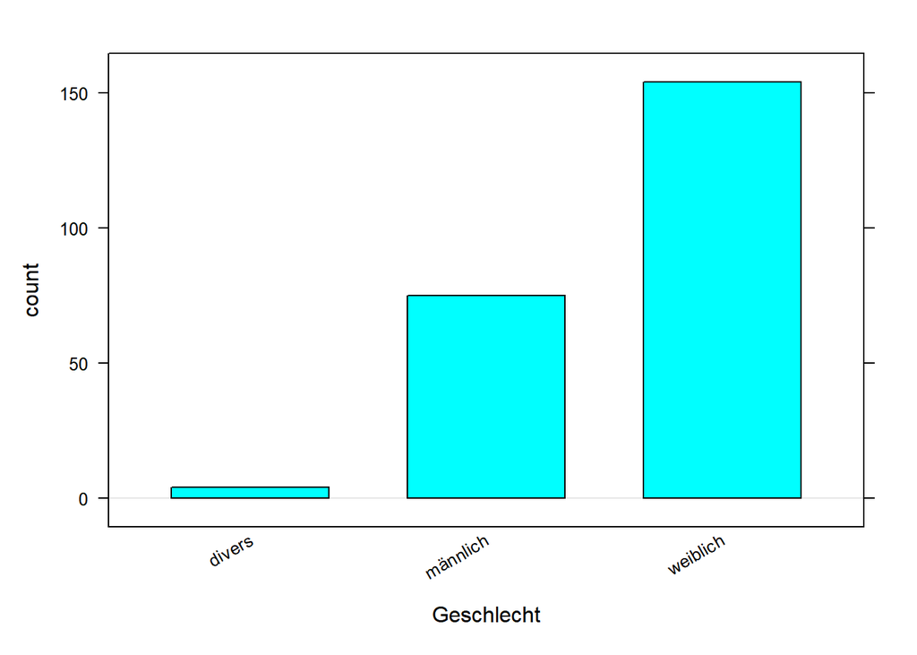

```r
bargraph (~Geschlecht, daten)
```

```r
tally(~Geschlecht, daten)
```

```
## Geschlecht
##   divers männlich weiblich
##        4       75      154
```

```r
tally(~Geschlecht, format = "percent" ,daten)
```

```
## Geschlecht
##    divers  männlich  weiblich
##  1.716738 32.188841 66.094421
```

Geschlecht Divers zu verlässigen wegen N = 4

```r
daten <- daten[daten$Geschlecht !='divers',] # Divers aus Datensatz entfernen
```

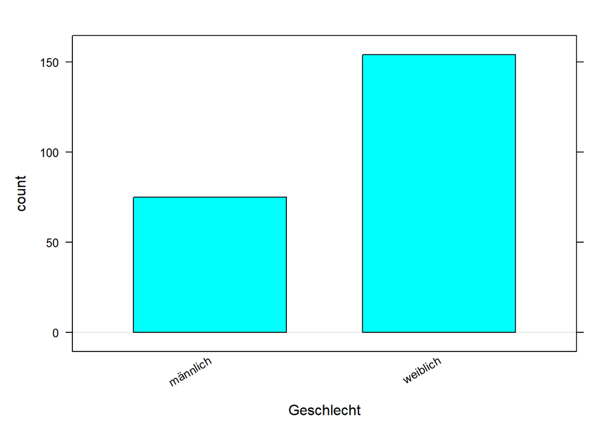

```r
bargraph (~Geschlecht, daten)
```

```r
tally(~Geschlecht, daten)
```

```
## Geschlecht
## männlich weiblich
##       75      154
```

```r
tally(~Geschlecht, format = "percent" ,daten)
```

```
## Geschlecht
## männlich weiblich
## 32.75109 67.24891
```

## Verteilung von Alter

```r
favstats(daten$Alter)
```

```
##  min Q1 median Q3 max     mean       sd   n missing
##   20 24     26 29  63 27.61572 6.932059 229       0
```

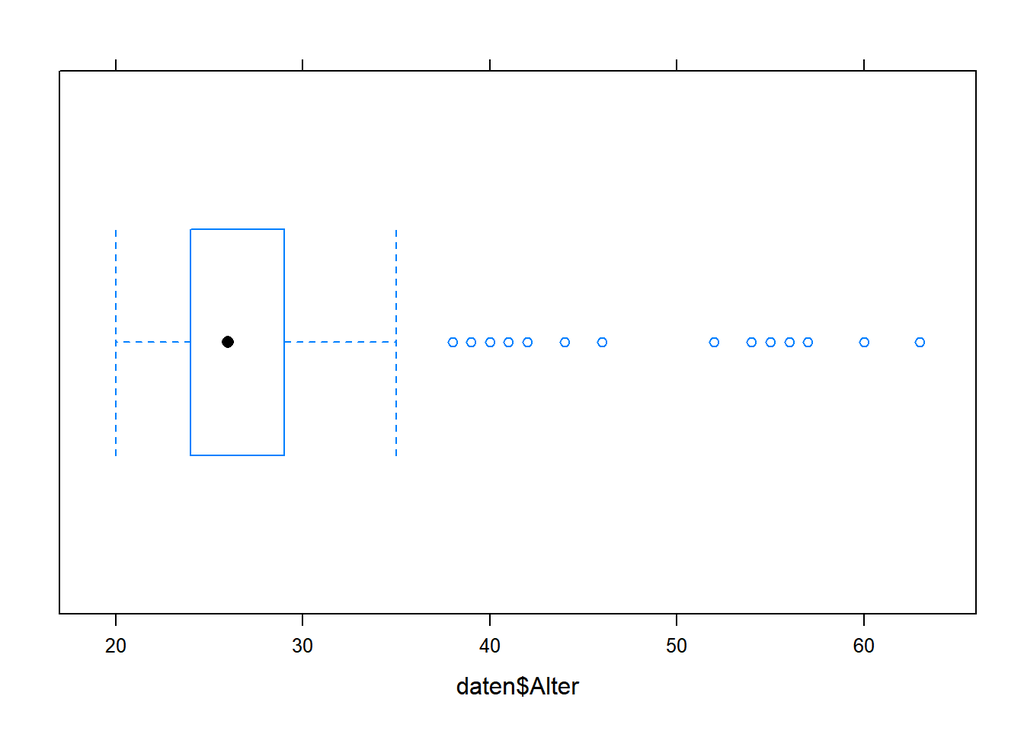

```r
bwplot(daten$Alter)
```

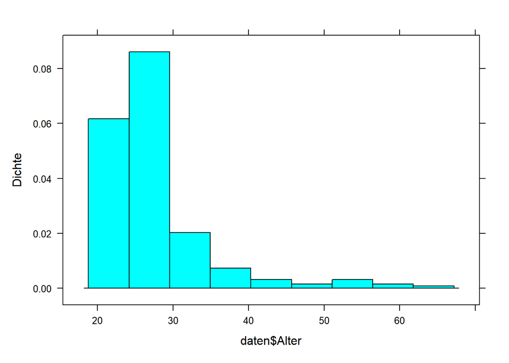

```r
histogram(daten$Alter)
```

## Verteilung von Dauer der Betriebszgehörigkeit

```r
favstats(daten$`DDB`)
```

```
##  min Q1 median Q3 max     mean       sd   n missing
##    1  2      4  6  54 5.017467 5.128152 229       0
```

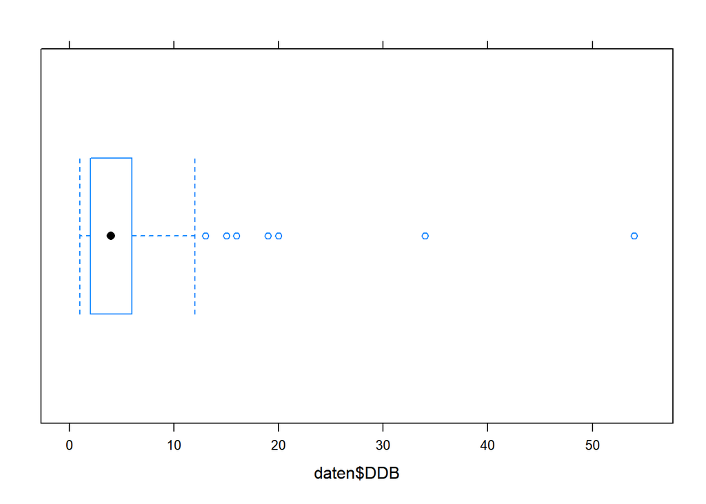

```r
bwplot(daten$`DDB`)
```

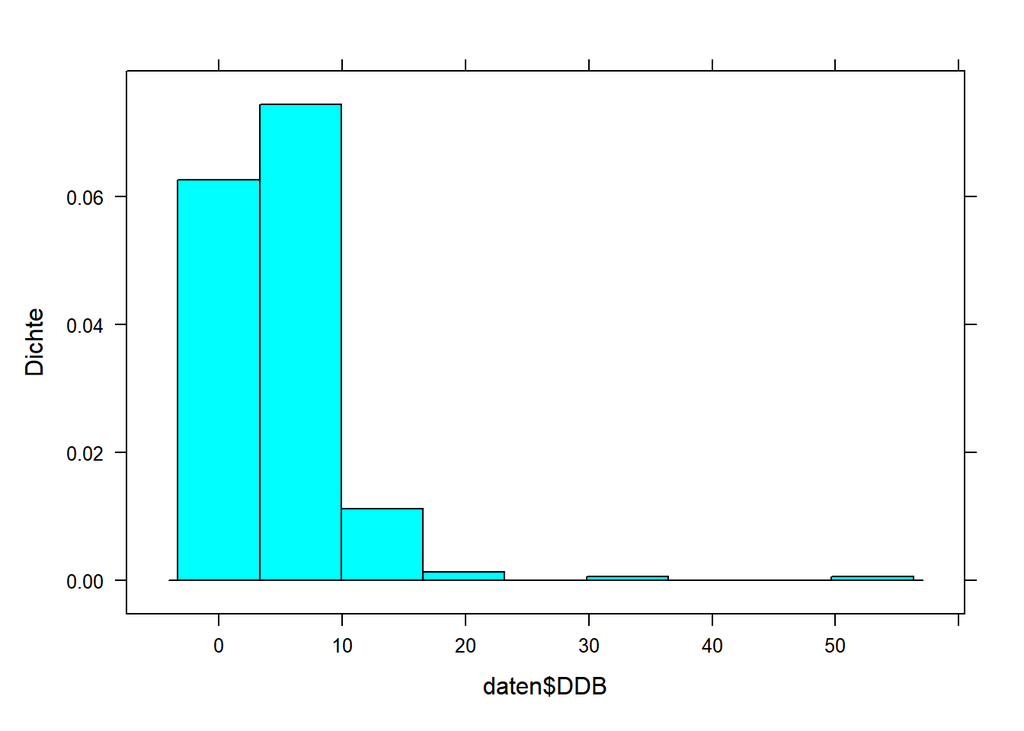

```r
histogram(daten$`DDB`)
```

# 2 Skalenkonstruktion

## 2.1 Dunkle Triade

Subskala Unsentimentaliät von MA (UNMA)

```r
daten$UNMA <- rowMeans(subset(daten, select = c(D02, D08, D26, D39, D49)))
```

Subkala Skepsis von MA (SKMA)

```r
daten$SKMA <- rowMeans(subset(daten, select = c(D24, D28, D43, D45, D57)))
```

Subkala Durchsetzungsglaube von MA (DUMA)

```r
daten$DUMA <- rowMeans(subset(daten, select = c(D06, D20, D22, D38, D42, D54, D55)))
```

Konstrukt MA insgesamt

```r
daten$MA <- rowMeans(subset(daten, select = c(UNMA, SKMA, DUMA)))
inspect(daten$MA)
```

```
## # A tibble: 1 x 10
##   class     min    Q1 median    Q3   max  mean    sd     n missing
## * <chr>   <dbl> <dbl>  <dbl> <dbl> <dbl> <dbl> <dbl> <int>   <int>
## 1 numeric  1.30  2.89   3.42  4.14  6.15  3.45 0.918   229       0
```

Subskala Führungsanspruch von NA (FUNA)

```r
daten$FUNA <- rowMeans(subset(daten, select = c(D01, D15, D17, D25, D40, D53, D56)))
```

Subskala Überzeugungsglaube von NA (ZENA)

```r
daten$ZENA <- rowMeans(subset(daten, select = c(D07, D11, D30, D31, D36, D46, D47, D48, D60)))
```

Subskala Autoritätsbedürfnis von NA (AUNA)

```r
daten$AUNA <- rowMeans(subset(daten, select = c(D13, D16, D21, D41)))
```

Subskala Risikofreude von NA (RINA)

```r
daten$RINA <- rowMeans(subset(daten, select = c(D12, D27, D51)))
```

Subskala Überlegenheitsgefühl von NA (LENA)

```r
daten$LENA <- rowMeans(subset(daten, select = c(D04, D10, D18, D23, D32, D35, D50, D59)))
```

Konstrukt NA (NAR) insgesamt

```r
daten$NAR <- rowMeans(subset(daten, select = c(FUNA, ZENA, AUNA, RINA, LENA)))
```

Subskala Flexibilität von Psychopathie (FLPP)

```r
daten$FLPP <- rowMeans(subset(daten, select = c(D03, D09, D19, D34, D44)))
```

Subskala Impulsivität von Psychopathie (IMPP)

```r
daten$IMPP <- rowMeans(subset(daten, select = c(D05, D33, D37)))
```

Subskala Beschönigung von Psychopathie (BEPP)

```r
daten$BEPP <- rowMeans(subset(daten, select = c(D14, D29, D52, D58)))
```

Konstrukt Psychopathie (PP) insgesamt

```r
daten$PP <- rowMeans(subset(daten, select = c(FLPP, IMPP, BEPP)))
```

Konsrukt Dunkle Triade insgesamt

```r
daten$DT <- rowMeans(subset(daten, select = c(MA, NAR, PP)))
```

## 2.2 OCB

Subskala OCB-Hilfsbereitschaft bilden

```r
daten$OCBH<- rowMeans(subset(daten, select = c(OC01_01, OC01_05, OC01_09, OC01_13, OC01_17)))
```

Subskala OCB-Gewissenhaftigkeit

```r
daten$OCBG <- rowMeans(subset(daten, select = c(OC01_02, OC01_06, OC01_10, OC01_14, OC01_18)))
```

Subskala OCB-Unkompliziertheit

```r
daten$OCBU <- rowMeans(subset(daten, select = c(OC01_03, OC01_07, OC01_11, OC01_15, OC01_19)))
```

Subskala OCB-Eigeninitative

```r
daten$OCBE <- rowMeans(subset(daten, select = c(OC01_04, OC01_08, OC01_12, OC01_16, OC01_20)))
```

Konstrukt OCB insgesamt

```r
daten$OCB <- rowMeans(subset(daten, select = c(OCBH, OCBG, OCBU, OCBE)))
```

## 2.3 Soziale Kompetenzen

Subskala soziale Orientierung

```r
daten$SKSO <- rowMeans(subset(daten, select = c(I1, I5, I9, I14, I18, I21, I23, I27, I31)))
```

Subskala Offensivität

```r
daten$SKO <- rowMeans(subset(daten, select = c(I2, I6, I10, I15, I19, I24, I28, I32)))
```

Subskala Selbststeuerung

```r
daten$SKSS <- rowMeans(subset(daten, select = c(I3, I7, I11, I16, I12, I20, I24, I25, I33)))
```

Subskala Reflexibilität

```r
daten$SKR <- rowMeans(subset(daten, select = c(I4, I8, I13, I17, I22, I26, I30, I25)))
```

Konstrukt soziale Kompetenzen insgesamt

```r
daten$SK <- rowMeans(subset(daten, select = c(SKSO, SKO, SKSS,SKR)))
```

# 3 Reliabilitäten und Trennschärfe der Konstrukte

## 3.1 MA

Trennschärfeanalyse

rit unter .3 (Döring & Bortz, 2016, S.478) -> eliminieren

```r
library(psychometric)
```

Trennschärfenalyse Subskala Unsentimentalität

```r
TS_UNMA <- as.data.frame(cbind(daten$D02, daten$D08, daten$D26, daten$D39, daten$D49))
tab <- item.exam(TS_UNMA, discrim = TRUE)
tab
```

```
##    Sample.SD Item.total Item.Tot.woi Difficulty Discrimination Item.Criterion
## V1  1.444032  0.7593957    0.6025364   3.340611       2.342105             NA
## V2  1.343199  0.6210919    0.4284494   4.205240       1.802632             NA
## V3  1.575496  0.8100304    0.6616392   3.790393       2.828947             NA
## V4  1.587896  0.5540768    0.2972544   3.069869       1.973684             NA
## V5  1.543143  0.8408298    0.7154050   3.462882       2.947368             NA
##    Item.Reliab Item.Rel.woi Item.Validity
## V1   1.0941950    0.8681802            NA
## V2   0.8324264    0.5742348            NA
## V3   1.2734103    1.0401314            NA
## V4   0.8778931    0.4709773            NA
## V5   1.2946848    1.1015594            NA
```

Cronbach alpha Unsentimentalität

```r
psychometric::alpha(TS_UNMA)
```

```
## [1] 0.7638967
```

Trennschärfenalyse Subskala Skepsis

```r
TS_SKMA <- as.data.frame(cbind(daten$D24, daten$D28, daten$D43, daten$D45, daten$D57))
tab <- item.exam(TS_SKMA, discrim = TRUE)
tab
```

```
##    Sample.SD Item.total Item.Tot.woi Difficulty Discrimination Item.Criterion
## V1  1.672475  0.7330255    0.5449409   3.419214       2.750000             NA
## V2  1.526785  0.7987390    0.6631885   2.895197       2.736842             NA
## V3  1.463072  0.7161883    0.5517148   3.349345       2.342105             NA
## V4  1.480471  0.7880146    0.6527479   3.681223       2.513158             NA
## V5  1.573927  0.6915170    0.5005899   3.751092       2.434211             NA
##    Item.Reliab Item.Rel.woi Item.Validity
## V1    1.223287    0.9094079            NA
## V2    1.216837    1.0103332            NA
## V3    1.045545    0.8054342            NA
## V4    1.164083    0.9642622            NA
## V5    1.086018    0.7861699            NA
```

Cronbach alpha Skepsis:

```r
psychometric::alpha(TS_SKMA)
```

```
## [1] 0.7984014
```

Trennschärfe Subskala Durchsetzungsglaube

```r
TS_DUMA <- as.data.frame(cbind(daten$dD06, daten$D20, daten$D22, daten$D38, daten$D42, daten$D54, daten$D55))
tab <- item.exam(TS_DUMA, discrim = TRUE)
tab
```

```
##    Sample.SD Item.total Item.Tot.woi Difficulty Discrimination Item.Criterion
## V1  1.555875  0.7800435    0.6521124   4.017467       2.789474             NA
## V2  1.520059  0.7136386    0.5631493   3.248908       2.342105             NA
## V3  1.466446  0.7829151    0.6657003   2.755459       2.697368             NA
## V4  1.508397  0.4615324    0.2479952   4.799127       1.381579             NA
## V5  1.601515  0.7085973    0.5458567   2.969432       2.421053             NA
## V6  1.531295  0.7553288    0.6196117   2.606987       2.460526             NA
##    Item.Reliab Item.Rel.woi Item.Validity
## V1   1.2109972    1.0123875            NA
## V2   1.0824018    0.8541491            NA
## V3   1.1455931    0.9740797            NA
## V4   0.6946525    0.3732577            NA
## V5   1.1323489    0.8722870            NA
## V6   1.1541027    0.9467342            NA
```

Cronbach alpha Durchsetzungsglaube

```r
psychometric::alpha(TS_DUMA)
```

```
## [1] 0.792252
```

## Cronbach alpha für MA

```r
MAalpha <- as.data.frame(cbind(daten$dD06, daten$D20, daten$D22, daten$D38, daten$D42, daten$D54, daten$D55, daten$D24, daten$D28, daten$D43, daten$D45, daten$D57, daten$D02, daten$D08, daten$D26, daten$D39, daten$D49))
tab <- item.exam(MAalpha, discrim = TRUE)
tab
```

```
##     Sample.SD Item.total Item.Tot.woi Difficulty Discrimination Item.Criterion
## V1   1.555875  0.6766024    0.6125779   4.017467       2.276316             NA
## V2   1.520059  0.6665738    0.6027434   3.248908       2.289474             NA
## V3   1.466446  0.6779034    0.6181189   2.755459       2.289474             NA
## V4   1.508397  0.4783914    0.3933460   4.799127       1.421053             NA
## V5   1.601515  0.5219591    0.4357329   2.969432       1.710526             NA
## V6   1.531295  0.6453580    0.5780361   2.606987       2.157895             NA
## V7   1.672475  0.5347468    0.4458398   3.419214       2.092105             NA
## V8   1.526785  0.6777884    0.6152619   2.895197       2.368421             NA
## V9   1.463072  0.7026727    0.6465779   3.349345       2.250000             NA
## V10  1.480471  0.6646564    0.6023936   3.681223       2.131579             NA
## V11  1.573927  0.5575013    0.4768320   3.751092       1.815789             NA
## V12  1.444032  0.4854588    0.4049067   3.340611       1.578947             NA
## V13  1.343199  0.4899432    0.4157448   4.205240       1.447368             NA
## V14  1.575496  0.6924061    0.6298933   3.790393       2.434211             NA
## V15  1.587896  0.4624378    0.3710963   3.069869       1.578947             NA
## V16  1.543143  0.6997988    0.6398408   3.462882       2.394737             NA
##     Item.Reliab Item.Rel.woi Item.Validity
## V1    1.0504077    0.9510111            NA
## V2    1.0110169    0.9142030            NA
## V3    0.9919357    0.9044566            NA
## V4    0.7200270    0.5920251            NA
## V5    0.8340982    0.6963075            NA
## V6    0.9860731    0.8832088            NA
## V7    0.8923959    0.7440260            NA
## V8    1.0325754    0.9373195            NA
## V9    1.0258138    0.9439226            NA
## V10   0.9818538    0.8898771            NA
## V11   0.8755485    0.7488583            NA
## V12   0.6994859    0.5834204            NA
## V13   0.6566526    0.5572073            NA
## V14   1.0884986    0.9902253            NA
## V15   0.7326979    0.5879743            NA
## V16   1.0775294    0.9852080            NA
```

```r
psychometric::alpha(MAalpha) # Cronbach alpha für MA
```

```
## [1] 0.882367
```

## 3.2 NA

Trennschärfe Subskala Führungsanspruch

```r
TS_FUNA <- as.data.frame(cbind(daten$D01, daten$D15, daten$D17, daten$D25, daten$D40, daten$D53, daten$D56))
tab <- item.exam(TS_FUNA, discrim = TRUE)
tab
```

```
##    Sample.SD Item.total Item.Tot.woi Difficulty Discrimination Item.Criterion
## V1  1.180033  0.7200446    0.6390013   4.895197       1.868421             NA
## V2  1.607364  0.8056793    0.7174686   4.471616       2.921053             NA
## V3  1.361497  0.8711263    0.8207423   4.358079       2.552632             NA
## V4  1.531670  0.7442151    0.6410213   4.021834       2.578947             NA
## V5  1.389209  0.8846885    0.8379057   4.065502       2.723684             NA
## V6  1.425155  0.8923097    0.8468806   3.781659       2.802632             NA
## V7  1.406990  0.8865660    0.8397232   4.205240       2.631579             NA
##    Item.Reliab Item.Rel.woi Item.Validity
## V1   0.8478189    0.7523942            NA
## V2   1.2921897    1.1507128            NA
## V3   1.1834432    1.1149954            NA
## V4   1.1374003    0.9796869            NA
## V5   1.2263307    1.1614817            NA
## V6   1.2688996    1.2042977            NA
## V7   1.2446632    1.1788999            NA
```

Cronbach alpha Führungsanspruch

```r
psychometric::alpha(TS_FUNA)
```

```
## [1] 0.9228505
```

Trennschärfe Subskala Überzeugungsglaube

```r
TS_ZENA<- as.data.frame(cbind(daten$D07, daten$D11, daten$D30, daten$D31, daten$D36, daten$D46, daten$D47, daten$D48, daten$D60))
tab <- item.exam(TS_ZENA, discrim = TRUE)
tab
```

```
##    Sample.SD Item.total Item.Tot.woi Difficulty Discrimination Item.Criterion
## V1  1.164955  0.6890026    0.5948196   5.082969       1.842105             NA
## V2  1.148630  0.7147429    0.6278517   4.751092       1.789474             NA
## V3  1.162783  0.5574990    0.4385158   3.890830       1.355263             NA
## V4  1.186475  0.7526947    0.6718359   4.986900       1.986842             NA
## V5  1.169435  0.6723372    0.5741041   4.703057       1.671053             NA
## V6  1.055097  0.7140329    0.6351533   4.882096       1.552632             NA
## V7  1.341287  0.7252447    0.6237412   4.615721       2.197368             NA
## V8  1.191066  0.7720509    0.6959204   4.371179       2.013158             NA
## V9  1.418554  0.7271289    0.6190779   4.135371       2.289474             NA
##    Item.Reliab Item.Rel.woi Item.Validity
## V1   0.8009028    0.6914236            NA
## V2   0.8191810    0.7195933            NA
## V3   0.6468335    0.5087842            NA
## V4   0.8911012    0.7953740            NA
## V5   0.7845361    0.6699100            NA
## V6   0.7517276    0.6686838            NA
## V7   0.9706348    0.8347872            NA
## V8   0.9175540    0.8270757            NA
## V9   1.0292172    0.8762760            NA
```

Cronbach alpha Überzeugungsglaube

```r
psychometric::alpha(TS_ZENA)
```

```
## [1] 0.8708335
```

Trennschärfe Subskala Autoritätsbedürfnis

```r
TS_AUNA <- as.data.frame(cbind(daten$D13, daten$D16, daten$D21, daten$D41))
tab <- item.exam(TS_AUNA, discrim = TRUE)
tab
```

```
##    Sample.SD Item.total Item.Tot.woi Difficulty Discrimination Item.Criterion
## V1  1.407317  0.7129022    0.5207664   2.956332       2.276316             NA
## V2  1.526321  0.8903778    0.7872328   3.480349       3.026316             NA
## V3  1.552301  0.8423572    0.6997383   3.292576       2.881579             NA
## V4  1.518761  0.8335374    0.6894352   3.576419       2.723684             NA
##    Item.Reliab Item.Rel.woi Item.Validity
## V1    1.001086    0.7312814            NA
## V2    1.356032    1.1989436            NA
## V3    1.304734    1.0838301            NA
## V4    1.263177    1.0447984            NA
```

Cronbach alpha Autoritätsbedürfnis

```r
psychometric::alpha(TS_AUNA)
```

```
## [1] 0.8393202
```

Trennschärfe Subskala Risikofreude

```r
TS_RINA <- as.data.frame(cbind(daten$D12, daten$D27, daten$D51))
tab <- item.exam(TS_RINA, discrim = TRUE)
tab
```

```
##    Sample.SD Item.total Item.Tot.woi Difficulty Discrimination Item.Criterion
## V1  1.419040  0.7920507    0.5296093   4.475983       2.407895             NA
## V2  1.421104  0.7918528    0.5286533   4.441048       2.513158             NA
## V3  1.505181  0.8000267    0.5188875   3.716157       2.684211             NA
##    Item.Reliab Item.Rel.woi Item.Validity
## V1    1.121495    0.7498942            NA
## V2    1.122845    0.7496290            NA
## V3    1.201553    0.7793127            NA
```

Cronbach alpha Risikofreude

```r
psychometric::alpha(TS_RINA)
```

```
## [1] 0.7077842
```

Trennschärfe Subskala Überlegenheitsgefühl

```r
TS_LENA <- as.data.frame(cbind(daten$D04, daten$D10, daten$D18, daten$D23, daten$D32, daten$D35, daten$D50, daten$D59))
tab <- item.exam(TS_LENA, discrim = TRUE)
tab
```

```
##    Sample.SD Item.total Item.Tot.woi Difficulty Discrimination Item.Criterion
## V1  1.589053  0.7901573    0.7074337   3.034934       2.881579             NA
## V2  1.535816  0.8051164    0.7304478   3.240175       2.736842             NA
## V3  1.369380  0.7757247    0.7028060   4.192140       2.289474             NA
## V4  1.275817  0.6558724    0.5628355   2.475983       1.763158             NA
## V5  1.392761  0.7474835    0.6657129   3.890830       2.131579             NA
## V6  1.372984  0.8438074    0.7898569   3.742358       2.473684             NA
## V7  1.450121  0.8662437    0.8158919   3.371179       2.868421             NA
## V8  1.439329  0.7967197    0.7252828   3.842795       2.526316             NA
##    Item.Reliab Item.Rel.woi Item.Validity
## V1   1.2528576    1.1216926            NA
## V2   1.2338076    1.1193810            NA
## V3   1.0599399    0.9603047            NA
## V4   0.8349444    0.7165058            NA
## V5   1.0387906    0.9251525            NA
## V6   1.1560014    1.0820902            NA
## V7   1.2534122    1.1805555            NA
## V8   1.1442357    1.0416391            NA
```

Cronbach alpha Überlegenheitsgefühl

```r
psychometric::alpha(TS_LENA)
```

```
## [1] 0.911333
```

## Cronbach alpha NAR

```r
NARalpha <- as.data.frame(cbind(daten$D01, daten$D15, daten$D17, daten$D25, daten$D40, daten$D53, daten$D56, daten$D07, daten$D11, daten$D30, daten$D31, daten$D36, daten$D46, daten$D47, daten$D48, daten$D60, daten$D13, daten$D16, daten$D21, daten$D41, daten$D12, daten$D27, daten$D51, daten$D04, daten$D10, daten$D18, daten$D23, daten$D32, daten$D35, daten$D50, daten$D59))
tab <- item.exam(TS_LENA, discrim = TRUE)
tab
```

```
##    Sample.SD Item.total Item.Tot.woi Difficulty Discrimination Item.Criterion
## V1  1.589053  0.7901573    0.7074337   3.034934       2.881579             NA
## V2  1.535816  0.8051164    0.7304478   3.240175       2.736842             NA
## V3  1.369380  0.7757247    0.7028060   4.192140       2.289474             NA
## V4  1.275817  0.6558724    0.5628355   2.475983       1.763158             NA
## V5  1.392761  0.7474835    0.6657129   3.890830       2.131579             NA
## V6  1.372984  0.8438074    0.7898569   3.742358       2.473684             NA
## V7  1.450121  0.8662437    0.8158919   3.371179       2.868421             NA
## V8  1.439329  0.7967197    0.7252828   3.842795       2.526316             NA
##    Item.Reliab Item.Rel.woi Item.Validity
## V1   1.2528576    1.1216926            NA
## V2   1.2338076    1.1193810            NA
## V3   1.0599399    0.9603047            NA
## V4   0.8349444    0.7165058            NA
## V5   1.0387906    0.9251525            NA
## V6   1.1560014    1.0820902            NA
## V7   1.2534122    1.1805555            NA
## V8   1.1442357    1.0416391            NA
```

```r
psychometric::alpha(NARalpha)
```

```
## [1] 0.9422707
```

## 3.3 PP

Trennschärfe Subskala Flexibilität

```r
TS_FLPP <- as.data.frame(cbind(daten$D03, daten$D09, daten$D19, daten$D34, daten$D44))
tab <- item.exam(TS_FLPP, discrim = TRUE)
tab
```

```
##    Sample.SD Item.total Item.Tot.woi Difficulty Discrimination Item.Criterion
## V1  1.390242  0.4736482    0.1506638   3.550218       1.315789             NA
## V2  1.313001  0.5353985    0.2465107   3.528384       1.671053             NA
## V3  1.793002  0.6013963    0.2006522   3.310044       2.368421             NA
## V4  1.443157  0.6777768    0.4047338   3.458515       2.210526             NA
## V5  1.309437  0.5177613    0.2255477   3.462882       1.500000             NA
##    Item.Reliab Item.Rel.woi Item.Validity
## V1   0.6570466    0.2090013            NA
## V2   0.7014422    0.3229613            NA
## V3   1.0759476    0.3589833            NA
## V4   0.9760001    0.5828176            NA
## V5   0.6764939    0.2946949            NA
```

Cronbach alpha Flexibilität

```r
psychometric::alpha(TS_FLPP)
```

```
## [1] 0.4550576
```

Trennschärfe Subskala Impulsivität

```r
TS_IMPP <- as.data.frame(cbind(daten$D05, daten$D33, daten$D37))
tab <- item.exam(TS_IMPP, discrim = TRUE)
tab
```

```
##    Sample.SD Item.total Item.Tot.woi Difficulty Discrimination Item.Criterion
## V1  1.628765  0.8127760    0.5622715   3.458515       2.973684             NA
## V2  1.475871  0.8673405    0.7014088   3.393013       2.815789             NA
## V3  1.494762  0.8731550    0.7095088   3.082969       3.013158             NA
##    Item.Reliab Item.Rel.woi Item.Validity
## V1    1.320928    0.9138066            NA
## V2    1.277285    1.0329266            NA
## V3    1.302306    1.0582287            NA
```

Cronbach alpha Impulsivität

```r
psychometric::alpha(TS_IMPP)
```

```
## [1] 0.8064436
```

Trennschärfe Subskala Beschönigung

```r
TS_BEPP <- as.data.frame(cbind(daten$D14, daten$D29, daten$D52, daten$D58))
tab <- item.exam(TS_BEPP, discrim = TRUE)
tab
```

```
##    Sample.SD Item.total Item.Tot.woi Difficulty Discrimination Item.Criterion
## V1  1.559183  0.7230995    0.4979694   3.262009       2.421053             NA
## V2  1.591919  0.7878383    0.5938109   3.257642       2.789474             NA
## V3  1.494019  0.7949751    0.6222146   3.637555       2.539474             NA
## V4  1.693189  0.7127378    0.4548271   3.847162       2.605263             NA
##    Item.Reliab Item.Rel.woi Item.Validity
## V1    1.124980    0.7747282            NA
## V2    1.251434    0.9432327            NA
## V3    1.185112    0.9275684            NA
## V4    1.204162    0.7684249            NA
```

Cronbach alpha Beschönigung

```r
psychometric::alpha(TS_BEPP)
```

```
## [1] 0.7450751
```

## Cronbach alpha PP

```r
PPalpha <- as.data.frame(cbind(daten$D03, daten$D09, daten$D19, daten$D34, daten$D44, daten$D05, daten$D33, daten$D37, daten$D14, daten$D29, daten$D52, daten$D58))
tab <- item.exam(PPalpha, discrim = TRUE)
tab
```

```
##     Sample.SD Item.total Item.Tot.woi Difficulty Discrimination Item.Criterion
## V1   1.390242  0.3287332    0.1787233   3.550218       1.157895             NA
## V2   1.313001  0.3681807    0.2299985   3.528384       1.171053             NA
## V3   1.793002  0.3192437    0.1220421   3.310044       1.171053             NA
## V4   1.443157  0.3645192    0.2113492   3.458515       1.144737             NA
## V5   1.309437  0.4781461    0.3518205   3.462882       1.263158             NA
## V6   1.628765  0.5096074    0.3537969   3.458515       1.947368             NA
## V7   1.475871  0.5831424    0.4560395   3.393013       2.000000             NA
## V8   1.494762  0.6420127    0.5250658   3.082969       2.210526             NA
## V9   1.559183  0.5791653    0.4430555   3.262009       1.894737             NA
## V10  1.591919  0.5941214    0.4577504   3.257642       1.986842             NA
## V11  1.494019  0.5923430    0.4652164   3.637555       1.789474             NA
## V12  1.693189  0.4699651    0.3009256   3.847162       1.565789             NA
##     Item.Reliab Item.Rel.woi Item.Validity
## V1    0.4560199    0.2479256            NA
## V2    0.4823649    0.3013281            NA
## V3    0.5711533    0.2183434            NA
## V4    0.5249085    0.3043433            NA
## V5    0.6247336    0.4596797            NA
## V6    0.8282167    0.5749926            NA
## V7    0.8587620    0.6715845            NA
## V8    0.9575586    0.7831330            NA
## V9    0.9010507    0.6892945            NA
## V10   0.9437260    0.7271088            NA
## V11   0.8830372    0.6935228            NA
## V12   0.7940003    0.5084102            NA
```

```r
psychometric::alpha(PPalpha)
```

```
## [1] 0.7032693
```

## 3.4 Cronbach Alpha OCB

## OCB

```r
OCBalpha <- as.data.frame(cbind(daten$OC01_01, daten$OC01_05, daten$OC01_09, daten$OC01_13, daten$OC01_17,
                                daten$OC01_02, daten$OC01_06, daten$OC01_10, daten$OC01_14, daten$OC01_18,
                                daten$OC01_03, daten$OC01_07, daten$OC01_11, daten$OC01_15, daten$OC01_19,
                                daten$OC01_04, daten$OC01_08, daten$OC01_12, daten$OC01_16, daten$OC01_20))
tab <- item.exam(OCBalpha, discrim = TRUE)
tab
```

```
##     Sample.SD Item.total Item.Tot.woi Difficulty Discrimination Item.Criterion
## V1   1.016620  0.5464185    0.4862153   5.777293      1.1447368             NA
## V2   1.220657  0.5050736    0.4278235   5.034934      1.3815789             NA
## V3   1.381564  0.6214029    0.5471273   5.366812      1.9736842             NA
## V4   1.028253  0.6118088    0.5569774   5.528384      1.2500000             NA
## V5   1.037266  0.6460697    0.5942946   5.746725      1.3421053             NA
## V6   1.381564  0.4611647    0.3686396   5.633188      1.2631579             NA
## V7   1.082815  0.5301639    0.4643155   6.126638      1.2368421             NA
## V8   1.352959  0.4762336    0.3871425   5.794760      1.3026316             NA
## V9   1.115539  0.5109696    0.4412993   5.318777      1.0526316             NA
## V10  1.683683  0.3355320    0.2100128   4.563319      1.2105263             NA
## V11  1.385910  0.5049222    0.4163743   5.017467      1.7631579             NA
## V12  1.403023  0.4725142    0.3795250   5.248908      1.5657895             NA
## V13  1.322941  0.4265149    0.3352646   5.598253      1.1052632             NA
## V14  1.390380  0.4195270    0.3227566   5.200873      1.3289474             NA
## V15  1.443488  0.2601401    0.1494649   4.908297      0.6052632             NA
## V16  1.288975  0.5358546    0.4570802   5.248908      1.4473684             NA
## V17  1.317791  0.5595314    0.4814702   5.209607      1.5000000             NA
## V18  1.283988  0.4872114    0.4039682   5.096070      1.3026316             NA
## V19  1.302706  0.5307148    0.4504921   5.187773      1.5263158             NA
## V20  1.342700  0.5146610    0.4300788   4.886463      1.4078947             NA
##     Item.Reliab Item.Rel.woi Item.Validity
## V1    0.5542860    0.4932161            NA
## V2    0.6151738    0.5210840            NA
## V3    0.8566312    0.7542390            NA
## V4    0.6277193    0.5714620            NA
## V5    0.6686815    0.6150943            NA
## V6    0.6357358    0.5081858            NA
## V7    0.5728148    0.5016690            NA
## V8    0.6429163    0.5226432            NA
## V9    0.5687605    0.4912104            NA
## V10   0.5636948    0.3528220            NA
## V11   0.6982471    0.5757960            NA
## V12   0.6614995    0.5313185            NA
## V13   0.5630206    0.4425657            NA
## V14   0.5820270    0.4477735            NA
## V15   0.3746885    0.2152793            NA
## V16   0.6891936    0.5878772            NA
## V17   0.7357339    0.6330904            NA
## V18   0.6242061    0.5175565            NA
## V19   0.6898542    0.5855760            NA
## V20   0.6895247    0.5762044            NA
```

```r
psychometric::alpha(OCBalpha)
```

```
## [1] 0.8302836
```

## Cronbach alpha OCBH

```r
OCBHalpha <- as.data.frame(cbind(daten$OC01_01, daten$OC01_05, daten$OC01_09, daten$OC01_13, daten$OC01_17))
tab <- item.exam(OCBHalpha, discrim = TRUE)
tab
```

```
##    Sample.SD Item.total Item.Tot.woi Difficulty Discrimination Item.Criterion
## V1  1.016620  0.6732621    0.4980321   5.777293       1.460526             NA
## V2  1.220657  0.6751301    0.4547153   5.034934       1.763158             NA
## V3  1.381564  0.7606795    0.5458057   5.366812       2.302632             NA
## V4  1.028253  0.7208095    0.5607008   5.528384       1.578947             NA
## V5  1.037266  0.7603449    0.6150833   5.746725       1.618421             NA
##    Item.Reliab Item.Rel.woi Item.Validity
## V1   0.6829559    0.5052030            NA
## V2   0.8223007    0.5538380            NA
## V3   1.0486301    0.7524172            NA
## V4   0.7395547    0.5752823            NA
## V5   0.7869562    0.6366106            NA
```

```r
psychometric::alpha(OCBHalpha)
```

```
## [1] 0.7592392
```

## OCBG

```r
OCBGalpha <- as.data.frame(cbind(daten$OC01_02, daten$OC01_06, daten$OC01_10, daten$OC01_14, daten$OC01_18))
tab <- item.exam(OCBGalpha, discrim = TRUE)
tab
```

```
##    Sample.SD Item.total Item.Tot.woi Difficulty Discrimination Item.Criterion
## V1  1.381564  0.7460761    0.5355493   5.633188       2.144737             NA
## V2  1.082815  0.6496902    0.4618974   6.126638       1.447368             NA
## V3  1.352959  0.6538369    0.4065860   5.794760       1.802632             NA
## V4  1.115539  0.6313564    0.4305131   5.318777       1.526316             NA
## V5  1.683683  0.5602946    0.1961267   4.563319       2.263158             NA
##    Item.Reliab Item.Rel.woi Item.Validity
## V1   1.0284987    0.7382782            NA
## V2   0.7019568    0.4990564            NA
## V3   0.8826811    0.5488919            NA
## V4   0.7027631    0.4792043            NA
## V5   0.9412966    0.3294935            NA
```

```r
psychometric::alpha(OCBGalpha)
```

```
## [1] 0.6326005
```

Item OC01_18 eliminieren da rit = .2

```r
OCBGalphaNEU <- as.data.frame(cbind(daten$OC01_02, daten$OC01_06, daten$OC01_10, daten$OC01_14))
tab <- item.exam(OCBGalphaNEU, discrim = TRUE)
tab
```

```
##    Sample.SD Item.total Item.Tot.woi Difficulty Discrimination Item.Criterion
## V1  1.381564  0.8221835    0.6105586   5.633188       2.315789             NA
## V2  1.082815  0.7436662    0.5525501   6.126638       1.631579             NA
## V3  1.352959  0.6494874    0.3390926   5.794760       1.868421             NA
## V4  1.115539  0.7028384    0.4838650   5.318777       1.671053             NA
##    Item.Reliab Item.Rel.woi Item.Validity
## V1   1.1334161    0.8416818            NA
## V2   0.8034930    0.5970019            NA
## V3   0.8768093    0.4577757            NA
## V4   0.7823296    0.5385903            NA
```

```r
psychometric::alpha(OCBGalphaNEU)
```

```
## [1] 0.7013653
```

Reliabilität von OCBG erhöht sich, wenn Item OC01_18 elimiminiert wird.

```r
OCBGalpha <- as.data.frame(cbind(daten$OC01_02, daten$OC01_06, daten$OC01_10, daten$OC01_14))
tab <- item.exam(OCBGalpha, discrim = TRUE)
tab
```

```
##    Sample.SD Item.total Item.Tot.woi Difficulty Discrimination Item.Criterion
## V1  1.381564  0.8221835    0.6105586   5.633188       2.315789             NA
## V2  1.082815  0.7436662    0.5525501   6.126638       1.631579             NA
## V3  1.352959  0.6494874    0.3390926   5.794760       1.868421             NA
## V4  1.115539  0.7028384    0.4838650   5.318777       1.671053             NA
##    Item.Reliab Item.Rel.woi Item.Validity
## V1   1.1334161    0.8416818            NA
## V2   0.8034930    0.5970019            NA
## V3   0.8768093    0.4577757            NA
## V4   0.7823296    0.5385903            NA
```

## OCBU

```r
OCBUalpha <- as.data.frame(cbind(daten$OC01_03, daten$OC01_07, daten$OC01_11, daten$OC01_15, daten$OC01_19))
tab <- item.exam(OCBUalpha, discrim = TRUE)
tab
```

```
##    Sample.SD Item.total Item.Tot.woi Difficulty Discrimination Item.Criterion
## V1  1.385910  0.7598514    0.5917012   5.017467       2.394737             NA
## V2  1.403023  0.7112964    0.5175138   5.248908       2.276316             NA
## V3  1.322941  0.7253401    0.5518134   5.598253       1.894737             NA
## V4  1.390380  0.7272308    0.5428089   5.200873       2.171053             NA
## V5  1.443488  0.6101390    0.3701585   4.908297       1.960526             NA
##    Item.Reliab Item.Rel.woi Item.Validity
## V1   1.0507837    0.8182520            NA
## V2   0.9957842    0.7244969            NA
## V3   0.9574845    0.7284208            NA
## V4   1.0089172    0.7530611            NA
## V5   0.8788035    0.5331516            NA
```

```r
psychometric::alpha(OCBUalpha)
```

```
## [1] 0.7477922
```

## OCBE

```r
OCBEalpha <- as.data.frame(cbind(daten$OC01_04, daten$OC01_08, daten$OC01_12, daten$OC01_16, daten$OC01_20))
tab <- item.exam(OCBEalpha, discrim = TRUE)
tab
```

```
##    Sample.SD Item.total Item.Tot.woi Difficulty Discrimination Item.Criterion
## V1  1.288975  0.7032453    0.5143195   5.248908       1.934211             NA
## V2  1.317791  0.7019224    0.5069161   5.209607       1.973684             NA
## V3  1.283988  0.7404693    0.5686900   5.096070       1.973684             NA
## V4  1.302706  0.7000301    0.5071442   5.187773       2.000000             NA
## V5  1.342700  0.7159380    0.5222204   4.886463       2.065789             NA
##    Item.Reliab Item.Rel.woi Item.Validity
## V1   0.9044844    0.6614960            NA
## V2   0.9229654    0.6665496            NA
## V3   0.9486754    0.7285951            NA
## V4   0.9099401    0.6592157            NA
## V5   0.9591885    0.6996525            NA
```

```r
psychometric::alpha(OCBEalpha)
```

```
## [1] 0.757075
```

## OCB neue Konstruktion ohne OC01_18

```r
daten$OCBG <- rowMeans(subset(daten, select = c(OC01_02, OC01_06, OC01_10, OC01_14)))
```

```r
daten$OCB <- rowMeans(subset(daten, select = c(OCBH, OCBG, OCBU, OCBE)))
```

```r
psychometric::alpha(OCBalpha)
```

```
## [1] 0.8302836
```

# Soziale Orientierung SO

```r
TS_SOSK <- as.data.frame(cbind(daten$I1, daten$I5, daten$I9, daten$I14, daten$I18, daten$I21, daten$I23, daten$I27, daten$I31)) #Trennschärfe
tab <- item.exam(TS_SOSK, discrim = TRUE)
tab
```

```
##    Sample.SD Item.total Item.Tot.woi Difficulty Discrimination Item.Criterion
## V1 0.6920215  0.4654139    0.2914972   3.366812      0.7105263             NA
## V2 0.7112119  0.5110915    0.3392393   3.126638      0.8157895             NA
## V3 0.8627794  0.6000438    0.4066298   3.034934      1.1578947             NA
## V4 0.6340162  0.4536365    0.2942134   2.847162      0.6842105             NA
## V5 0.8541452  0.5063699    0.2935754   2.842795      0.9342105             NA
## V6 0.8808813  0.5230906    0.3060475   2.637555      0.9868421             NA
## V7 0.7011499  0.5818620    0.4265786   3.323144      0.9210526             NA
## V8 0.7079189  0.5549293    0.3922443   2.943231      0.8157895             NA
## V9 0.6939837  0.5060084    0.3379898   2.703057      0.7631579             NA
##    Item.Reliab Item.Rel.woi Item.Validity
## V1   0.3213724    0.2012814            NA
## V2   0.3626998    0.2407437            NA
## V3   0.5165738    0.3500650            NA
## V4   0.2869842    0.1861283            NA
## V5   0.4315680    0.2502079            NA
## V6   0.4597736    0.2690022            NA
## V7   0.4070807    0.2984418            NA
## V8   0.3919863    0.2770702            NA
## V9   0.3503940    0.2340467            NA
```

```r
psychometric::alpha(TS_SOSK) #
```

```
## [1] 0.6651761
```

# Offensitivät (OF)

```r
TS_OF <- as.data.frame(cbind(daten$I2, daten$I6, daten$I10, daten$I15, daten$I19, daten$I24, daten$I28, daten$I32)) #Trennschärfe
tab <- item.exam(TS_OF, discrim = TRUE)
tab
```

```
##    Sample.SD Item.total Item.Tot.woi Difficulty Discrimination Item.Criterion
## V1 0.6820414  0.5161758    0.3647268   2.572052      0.7763158             NA
## V2 0.7888657  0.5204109    0.3426306   3.096070      0.8552632             NA
## V3 0.8495811  0.5280647    0.3360516   2.554585      1.0000000             NA
## V4 0.9063858  0.6560489    0.4826656   2.746725      1.2763158             NA
## V5 0.7579351  0.6116907    0.4609392   2.711790      0.9473684             NA
## V6 0.7695211  0.5182359    0.3450197   2.825328      0.8552632             NA
## V7 0.8640216  0.6133611    0.4376869   2.698690      1.2368421             NA
## V8 0.8660586  0.6657350    0.5047568   2.825328      1.1842105             NA
##    Item.Reliab Item.Rel.woi Item.Validity
## V1   0.3512838    0.2482150            NA
## V2   0.4096370    0.2696987            NA
## V3   0.4476531    0.2848791            NA
## V4   0.5933337    0.4365250            NA
## V5   0.4626085    0.3485984            NA
## V6   0.3979218    0.2649196            NA
## V7   0.5287989    0.3773444            NA
## V8   0.5753053    0.4361934            NA
```

```r
psychometric::alpha(TS_OF)
```

```
## [1] 0.7182452
```

# Selbststeuerung (SS)

```r
TS_SS <- as.data.frame(cbind(daten$dI3, daten$I7, daten$I11, daten$I16, daten$I12, daten$I20, daten$I24, daten$I25, daten$I33)) #Trennschärfe
tab <- item.exam(TS_SS, discrim = TRUE)
tab
```

```
##    Sample.SD Item.total Item.Tot.woi Difficulty Discrimination Item.Criterion
## V1 0.8585512  0.7413991    0.6062097   2.572052      1.4210526             NA
## V2 0.8017257  0.5595728    0.3842102   2.716157      1.0000000             NA
## V3 0.7323081  0.4618678    0.2870473   2.890830      0.7500000             NA
## V4 0.8197506  0.6375251    0.4769079   2.729258      1.1578947             NA
## V5 0.7646523  0.5083736    0.3325239   2.746725      0.8552632             NA
## V6 0.7695211  0.4090094    0.2171079   2.825328      0.6842105             NA
## V7 0.8810987  0.7917369    0.6729911   2.532751      1.5789474             NA
## V8 0.7520752  0.5153137    0.3439652   2.986900      0.8421053             NA
##    Item.Reliab Item.Rel.woi Item.Validity
## V1   0.6351378    0.5193245            NA
## V2   0.4476433    0.3073579            NA
## V3   0.3374902    0.2097476            NA
## V4   0.5214693    0.3900911            NA
## V5   0.3878794    0.2537094            NA
## V6   0.3140534    0.1667039            NA
## V7   0.6960736    0.5916755            NA
## V8   0.3867075    0.2581223            NA
```

```r
psychometric::alpha(TS_SS)
```

```
## [1] 0.7243902
```

# Reflexibilität (RE)

```r
TS_RE <- as.data.frame(cbind(daten$I4, daten$I8, daten$I13, daten$I17, daten$I22, daten$I26, daten$I30, daten$I25)) #Trennschärfe
tab <- item.exam(TS_RE, discrim = TRUE)
tab
```

```
##    Sample.SD Item.total Item.Tot.woi Difficulty Discrimination Item.Criterion
## V1 0.6424785 0.53378483    0.3390244   3.279476      0.7236842             NA
## V2 0.8275869 0.63707031    0.4055884   2.803493      1.0657895             NA
## V3 0.7016414 0.57304274    0.3665787   3.144105      0.8289474             NA
## V4 0.8205913 0.43476640    0.1559882   3.139738      0.8289474             NA
## V5 0.8210347 0.57133895    0.3214752   2.834061      0.9078947             NA
## V6 0.6882472 0.43166768    0.2022633   3.000000      0.7105263             NA
## V7 0.7706154 0.47124656    0.2174702   3.292576      0.7631579             NA
## V8 0.8810987 0.05289115   -0.2530817   2.532751      0.1052632             NA
##    Item.Reliab Item.Rel.woi Item.Validity
## V1  0.34219569    0.2173398            NA
## V2  0.52607860    0.3349260            NA
## V3  0.40119165    0.2566446            NA
## V4  0.35598571    0.1277228            NA
## V5  0.46806374    0.2633654            NA
## V6  0.29644469    0.1389029            NA
## V7  0.36235611    0.1672196            NA
## V8  0.04650046   -0.2225026            NA
```

```r
psychometric::alpha(TS_RE)
```

```
## [1] 0.4483292
```

Items unter rit = 3 eliminieren.

```r
TS_RE <- as.data.frame(cbind(daten$I4, daten$I8, daten$I13, daten$I22)) #Trennschärfe
tab <- item.exam(TS_RE, discrim = TRUE)
tab
```

```
##    Sample.SD Item.total Item.Tot.woi Difficulty Discrimination Item.Criterion
## V1 0.6424785  0.6709365    0.4382513   3.279476      0.9210526             NA
## V2 0.8275869  0.7445998    0.4602567   2.803493      1.4078947             NA
## V3 0.7016414  0.5839443    0.2900692   3.144105      0.8421053             NA
## V4 0.8210347  0.7545861    0.4801633   2.834061      1.2368421             NA
##    Item.Reliab Item.Rel.woi Item.Validity
## V1   0.4301201    0.2809516            NA
## V2   0.6148740    0.3800699            NA
## V3   0.4088239    0.2030797            NA
## V4   0.6181872    0.3933690            NA
```

```r
psychometric::alpha(TS_RE)
```

```
## [1] 0.6332534
```

# SK Cronbach alpha

```r
SKalpha <- as.data.frame(cbind(daten$I4, daten$I8, daten$I13, daten$I22, daten$I4, daten$I8, daten$I13, daten$I22, daten$dI3, daten$I7, daten$I11, daten$I16, daten$I12, daten$I20, daten$I24, daten$I25, daten$I33, daten$I2, daten$I6, daten$I10, daten$I15, daten$I19, daten$I24, daten$I28, daten$I32, daten$I1, daten$I5, daten$I9, daten$I14, daten$I18, daten$I21, daten$I23, daten$I27, daten$I31))
tab <- item.exam(OCBEalpha, discrim = TRUE)
tab
```

```
##    Sample.SD Item.total Item.Tot.woi Difficulty Discrimination Item.Criterion
## V1  1.288975  0.7032453    0.5143195   5.248908       1.934211             NA
## V2  1.317791  0.7019224    0.5069161   5.209607       1.973684             NA
## V3  1.283988  0.7404693    0.5686900   5.096070       1.973684             NA
## V4  1.302706  0.7000301    0.5071442   5.187773       2.000000             NA
## V5  1.342700  0.7159380    0.5222204   4.886463       2.065789             NA
##    Item.Reliab Item.Rel.woi Item.Validity
## V1   0.9044844    0.6614960            NA
## V2   0.9229654    0.6665496            NA
## V3   0.9486754    0.7285951            NA
## V4   0.9099401    0.6592157            NA
## V5   0.9591885    0.6996525            NA
```

```r
psychometric::alpha(SKalpha)
```

```
## [1] 0.7944326
```

## Interkorrelation der Skalen

```r
daten_interkor <- daten[, c("MA", "NAR", "PP", "OCB", "SK")]
```

```r
library(apaTables)
apa.cor.table(daten_interkor,
filename = "Table1Interkor.doc",
table.number = NA,
show.conf.interval = TRUE,
show.sig.stars = TRUE,
landscape = TRUE)
```

[output not shown]